# Connecticut Lake Profile Data

[figure not shown]

# Alexander Lake Report

*Report Last Updated: August 2024*

The [DEEP Water Monitoring Program](https://portal.ct.gov/deep/water/inland-water-monitoring/water-quality-monitoring-program) conducts ambient monitoring and the [related assessments](https://portal.ct.gov/deep/water/water-quality/water-quality-305b-report-to-congress) of the State’s waters, including Connecticut’s many [lakes and ponds](https://portal.ct.gov/deep/water/inland-water-monitoring/lake-water-quality-monitoring). In Connecticut, there are a total of 2,267 lakes and ponds greater than 10 acres in size.

The Monitoring Program conducts annual monitoring on approximately 10-20 of these lakes and ponds per year. The type and locations of monitoring during a given year is determined by a variety of factors, including participation in regional and national studies, as well as support requests from groups within DEEP.

## Monitoring Location(s)

[interactive chart not shown]

## Results

The below results were collected with a multiparameter probe. The first result is recorded at the surface of the lake, and each subsequent result is recorded one meter deeper. The final result is recorded approximately 0.5 meters from the bottom of the lake.

These results are first grouped according to the monitoring location, and then according to the date they were sampled. Click here to download the water chemistry profile data associated with these monitoring location(s).

### Station 18676

#### 2014-06-03

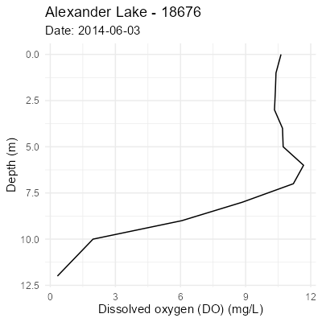

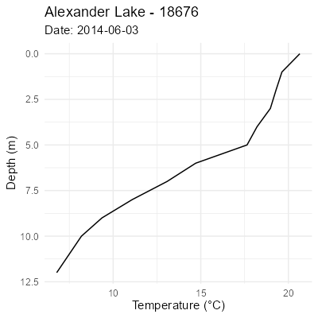

#### 2014-09-03

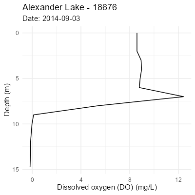

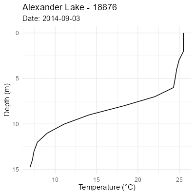

### Station 18677

#### 2014-06-03

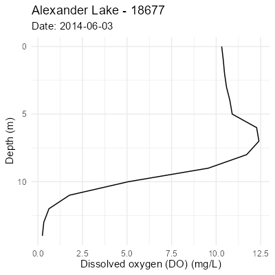

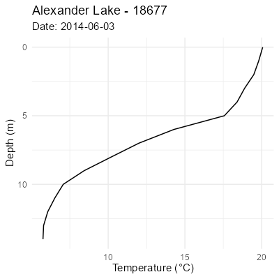

#### 2014-09-03

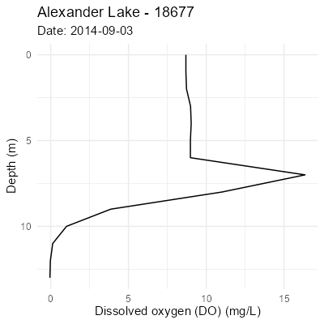

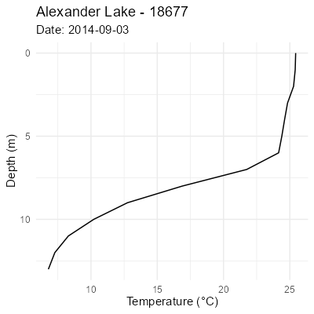